# LDMV_IIParcial_Practico

Luis Diego Montero Vargas

2025-11-12

# Parcial II | Exploración de Datos

### Profesor: Ronald Córdoba Vega

Este dataset asignado lo quise investigar mas a fondo sobre que trata, significado de cada variable y origen de los datos.

Encontre que corresponde a un estudio médico realizado en Sudáfrica con el propósito de analizar los factores de riesgo asociados a enfermedades coronarias. Cada registro representa un paciente y contiene información relacionada con sus características clínicas, hábitos y antecedentes familiares.

#### Fuente: https://r-packages.io/datasets/SAHeart

### Significado de variables

sbp - systolic blood pressure - integer  
tobacco - cumulative tobacco (kg) - numeric  
ldl - low density lipoprotein cholesterol - numeric  
adiposity - a numeric vector - numeric  
famhist - family history of heart disease, a factor with levels Absent Present - character  
typea - type-A behavior - integer  
obesity - a numeric vector - numeric  
alcohol - current alcohol consumption - numeric  
age - age at onset - integer  
chd - response, coronary heart disease - integer

# A. Carga de datos

El primer paso es importar el csv ya sabiendo el tipo de separador que posee

```r
datos<- read.csv("SAheart.csv", sep = ";")
```

# B. Resumen

## 1. Estadisticas basicas

Validacion de los datos cargados

```r
head(datos)
```

```
##   sbp tobacco  ldl adiposity famhist typea obesity alcohol age chd
## 1 160   12.00 5.73     23.11 Present    49   25.30   97.20  52  Si
## 2 144    0.01 4.41     28.61  Absent    55   28.87    2.06  63  Si
## 3 118    0.08 3.48     32.28 Present    52   29.14    3.81  46  No
## 4 170    7.50 6.41     38.03 Present    51   31.99   24.26  58  Si
## 5 134   13.60 3.50     27.78 Present    60   25.99   57.34  49  Si
## 6 132    6.20 6.47     36.21 Present    62   30.77   14.14  45  No
```

```r
tail(datos)
```

```
##     sbp tobacco   ldl adiposity famhist typea obesity alcohol age chd
## 457 170     0.4  4.11     42.06 Present    56   33.10    2.06  57  No
## 458 214     0.4  5.98     31.72  Absent    64   28.45    0.00  58  No
## 459 182     4.2  4.41     32.10  Absent    52   28.61   18.72  52  Si
## 460 108     3.0  1.59     15.23  Absent    40   20.09   26.64  55  No
## 461 118     5.4 11.61     30.79  Absent    64   27.35   23.97  40  No
## 462 132     0.0  4.82     33.41 Present    62   14.70    0.00  46  Si
```

```r
names(datos)
```

```
##  [1] "sbp"       "tobacco"   "ldl"       "adiposity" "famhist"   "typea"
##  [7] "obesity"   "alcohol"   "age"       "chd"
```

```r
summary(datos)
```

```
##       sbp           tobacco             ldl           adiposity
##  Min.   :101.0   Min.   : 0.0000   Min.   : 0.980   Min.   : 6.74
##  1st Qu.:124.0   1st Qu.: 0.0525   1st Qu.: 3.283   1st Qu.:19.77
##  Median :134.0   Median : 2.0000   Median : 4.340   Median :26.11
##  Mean   :138.3   Mean   : 3.6356   Mean   : 4.740   Mean   :25.41
##  3rd Qu.:148.0   3rd Qu.: 5.5000   3rd Qu.: 5.790   3rd Qu.:31.23
##  Max.   :218.0   Max.   :31.2000   Max.   :15.330   Max.   :42.49
##    famhist              typea         obesity         alcohol
##  Length:462         Min.   :13.0   Min.   :14.70   Min.   :  0.00
##  Class :character   1st Qu.:47.0   1st Qu.:22.98   1st Qu.:  0.51
##  Mode  :character   Median :53.0   Median :25.80   Median :  7.51
##                     Mean   :53.1   Mean   :26.04   Mean   : 17.04
##                     3rd Qu.:60.0   3rd Qu.:28.50   3rd Qu.: 23.89
##                     Max.   :78.0   Max.   :46.58   Max.   :147.19
##       age            chd
##  Min.   :15.00   Length:462
##  1st Qu.:31.00   Class :character
##  Median :45.00   Mode  :character
##  Mean   :42.82
##  3rd Qu.:55.00
##  Max.   :64.00
```

```r
str(datos)
```

```
## 'data.frame':    462 obs. of  10 variables:
##  $ sbp      : int  160 144 118 170 134 132 142 114 114 132 ...
##  $ tobacco  : num  12 0.01 0.08 7.5 13.6 6.2 4.05 4.08 0 0 ...
##  $ ldl      : num  5.73 4.41 3.48 6.41 3.5 6.47 3.38 4.59 3.83 5.8 ...
##  $ adiposity: num  23.1 28.6 32.3 38 27.8 ...
##  $ famhist  : chr  "Present" "Absent" "Present" "Present" ...
##  $ typea    : int  49 55 52 51 60 62 59 62 49 69 ...
##  $ obesity  : num  25.3 28.9 29.1 32 26 ...
##  $ alcohol  : num  97.2 2.06 3.81 24.26 57.34 ...
##  $ age      : int  52 63 46 58 49 45 38 58 29 53 ...
##  $ chd      : chr  "Si" "Si" "No" "Si" ...
```

Podemos observar que el dataset recibido posee 462 observaciones y 10 variables. De las cuales 2 son cualitativas y las otras 8 son cuantitativas.

# 2. Histogramas

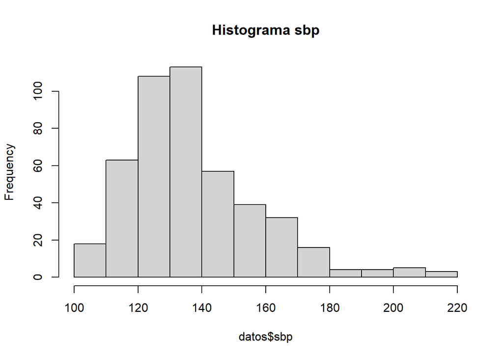

```r
hist(datos$sbp, main = "Histograma sbp")
```

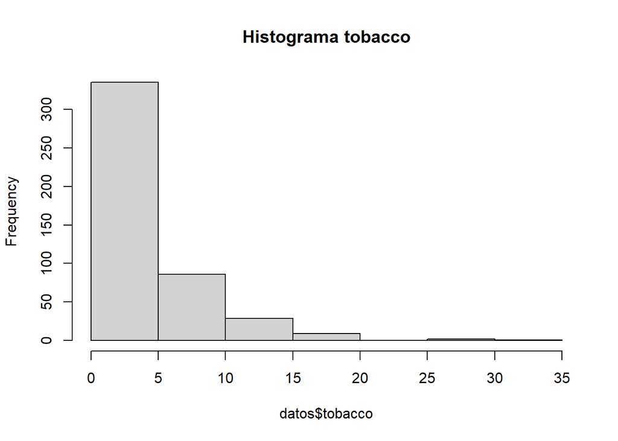

```r
hist(datos$tobacco, main = "Histograma tobacco")
```

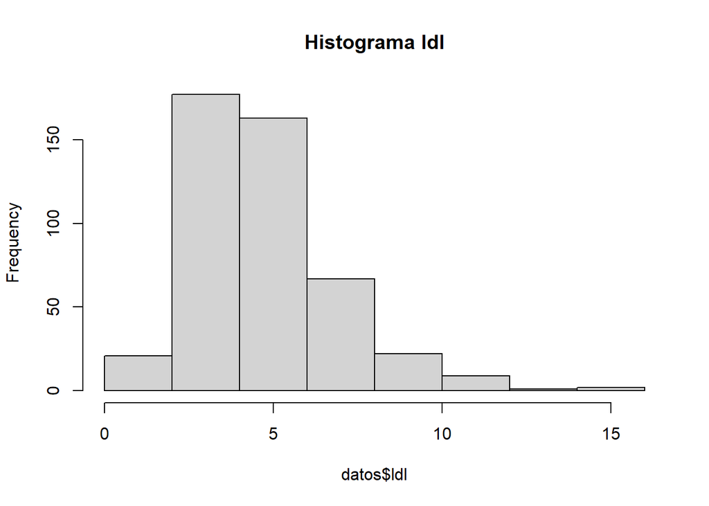

```r
hist(datos$ldl, main = "Histograma ldl")
```

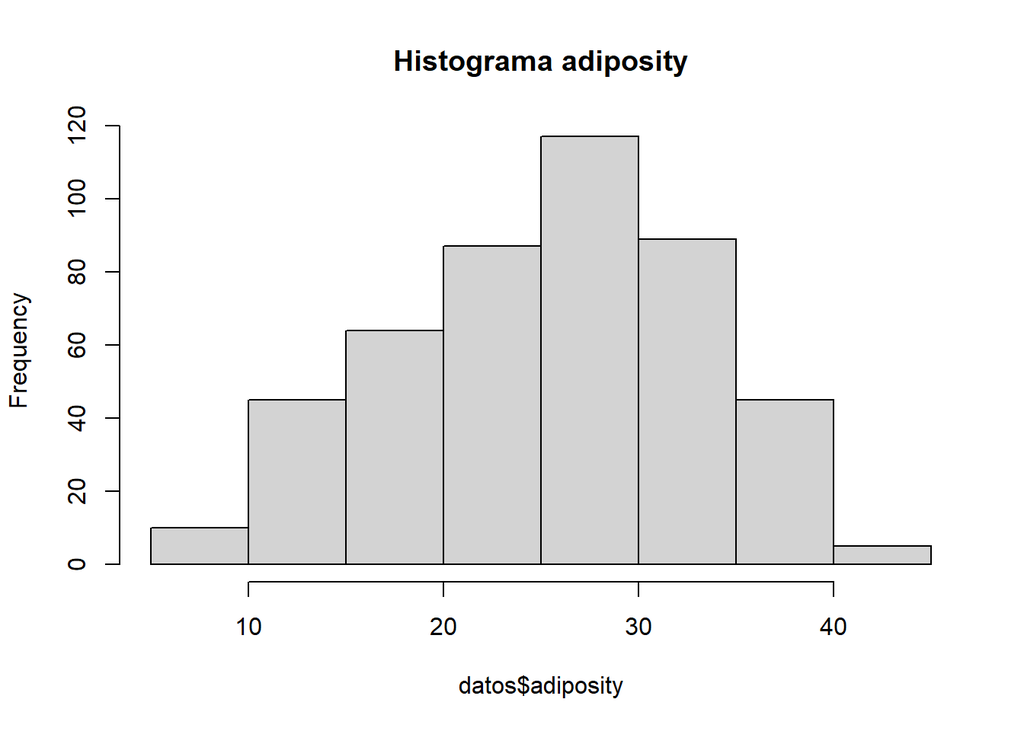

```r
hist(datos$adiposity, , main = "Histograma adiposity")
```

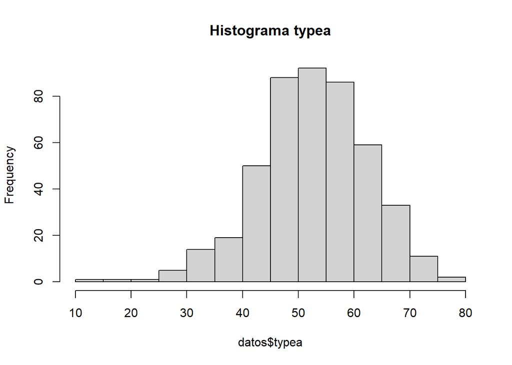

```r
hist(datos$typea, main = "Histograma typea")
```

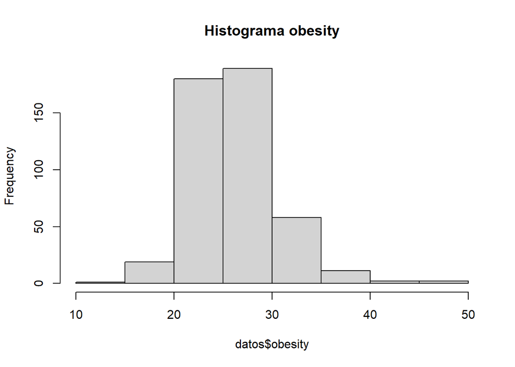

```r
hist(datos$obesity, main = "Histograma obesity")
```

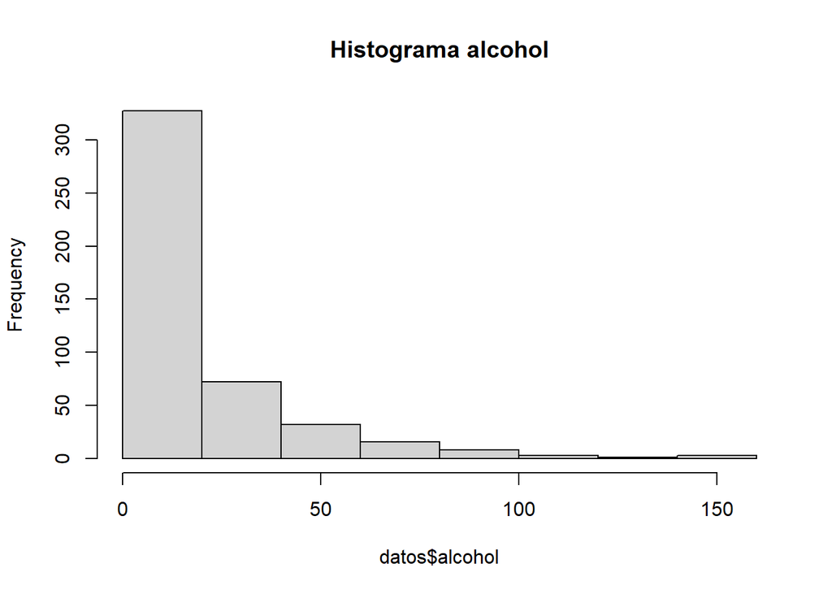

```r
hist(datos$alcohol, main = "Histograma alcohol")
```

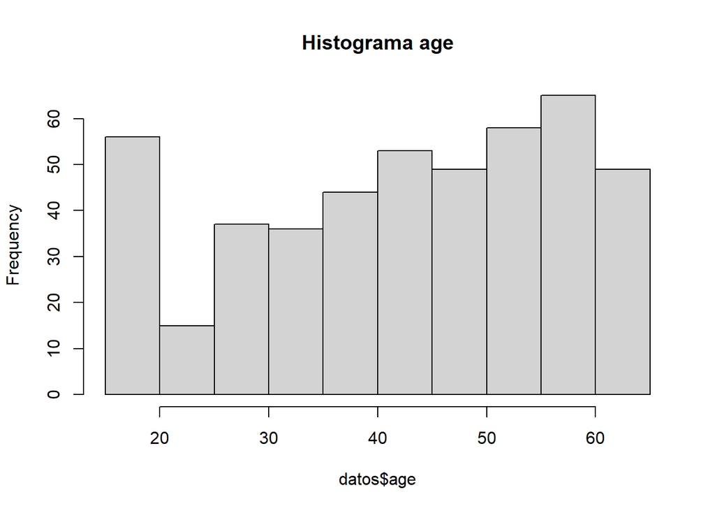

```r
hist(datos$age, main = "Histograma age")
```

En el caso los histogramas se pueden graficar todos los que su variable en el eje x sea cuantitativa. Es por eso que no se muestra la informacion de famhist y chd

#### Observaciones

sbp  
La distribución tiende a concentrarse entre valores medios de 120–150

tobacco  
La mayoría de los individuos tienen un consumo bajo o moderado, mientras que unos pocos presentan valores muy altos.

ldl  
La mayor cantidad de valores se encuentran entre 3-6

adiposity  
Tiene una distribución relativamente simétrica

typea  
Se observa que esta equilibrada en la distribicion de los datos con la gran mayoria entre 40-70

obesity  
Su gran mayoria de datos se encuentran entre 20-30

age  
La distribución de edades es asimétrica hacia la izquierda. Tiene sentido ya que las enfermedades del corazón son más comunes en altas edades

# 3. Boxplot

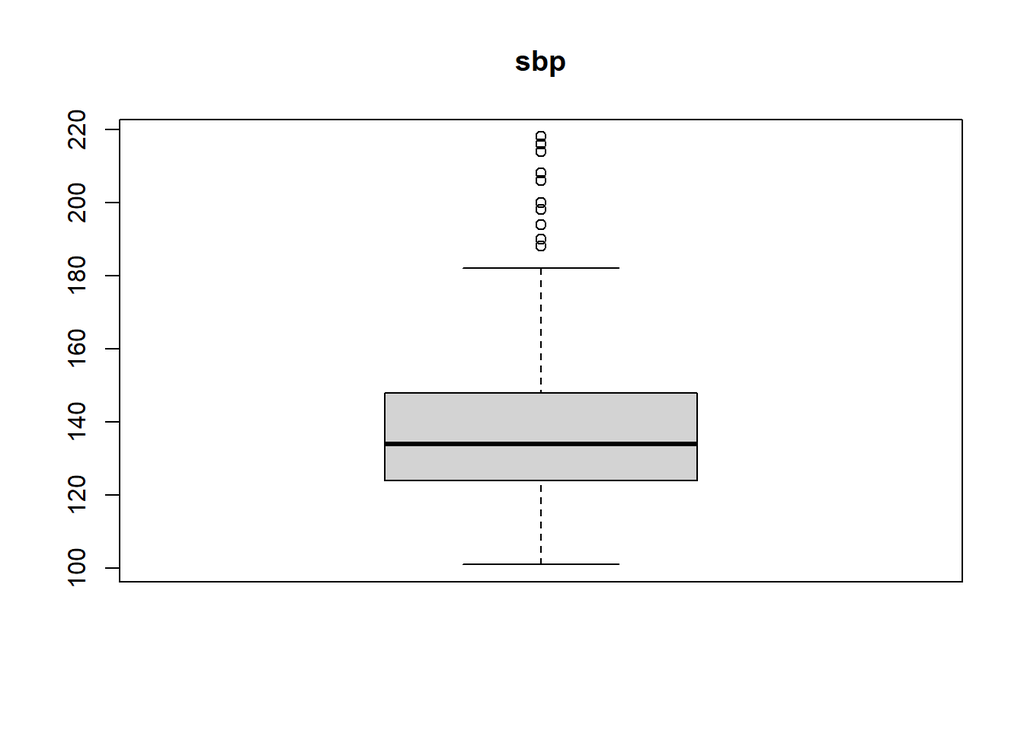

```r
boxplot(datos$sbp, main = "sbp")
```

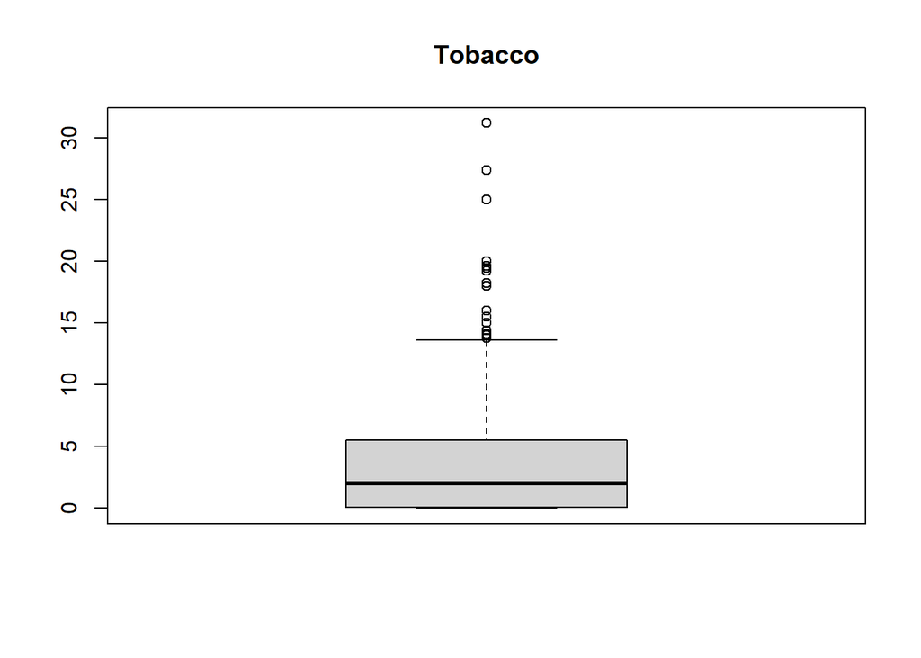

```r
boxplot(datos$tobacco, main= "Tobacco")
```

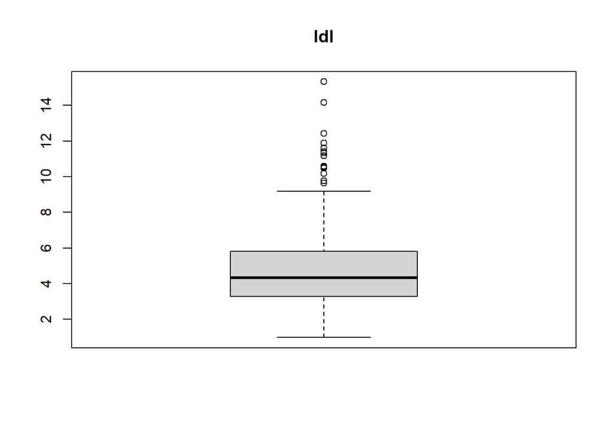

```r
boxplot(datos$ldl, main= "ldl")
```

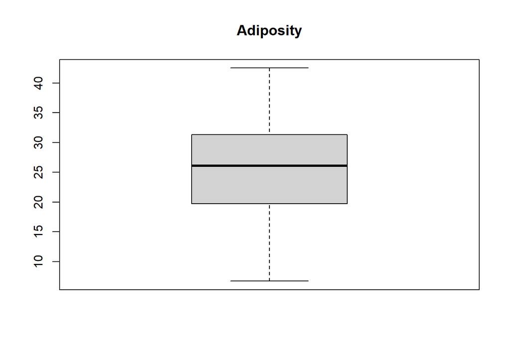

```r
boxplot(datos$adiposity, main="Adiposity")
```

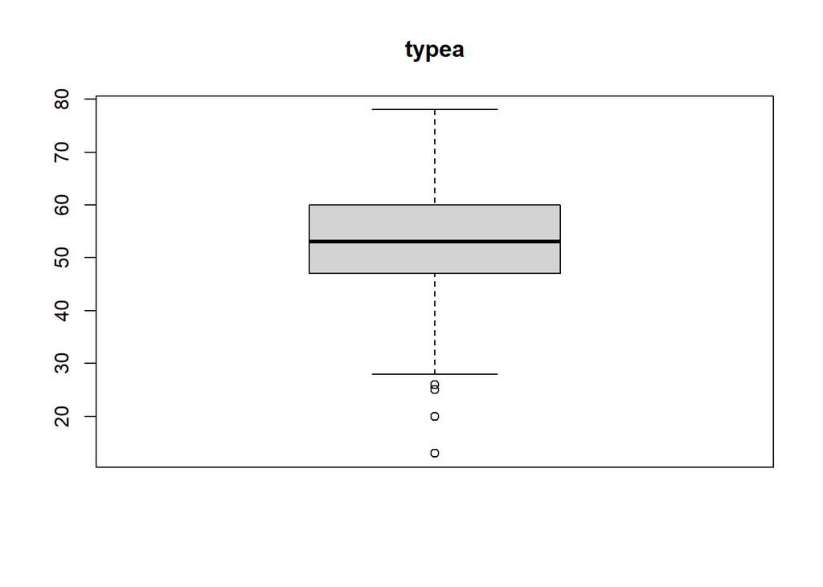

```r
boxplot(datos$typea, main="typea")
```

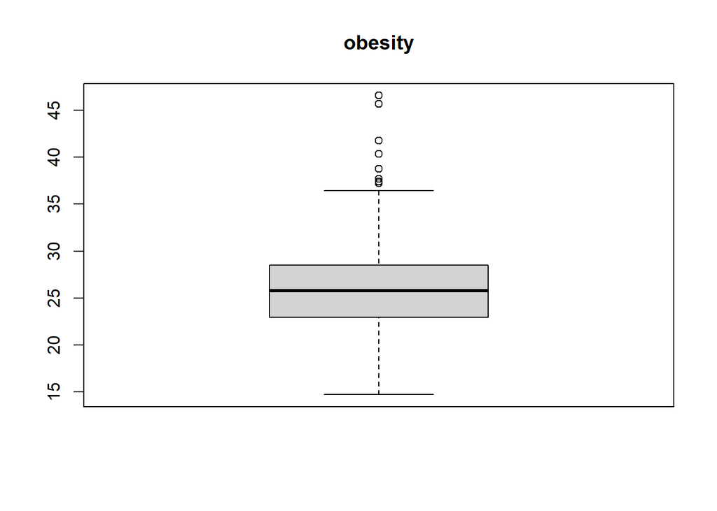

```r
boxplot(datos$obesity, main="obesity")
```

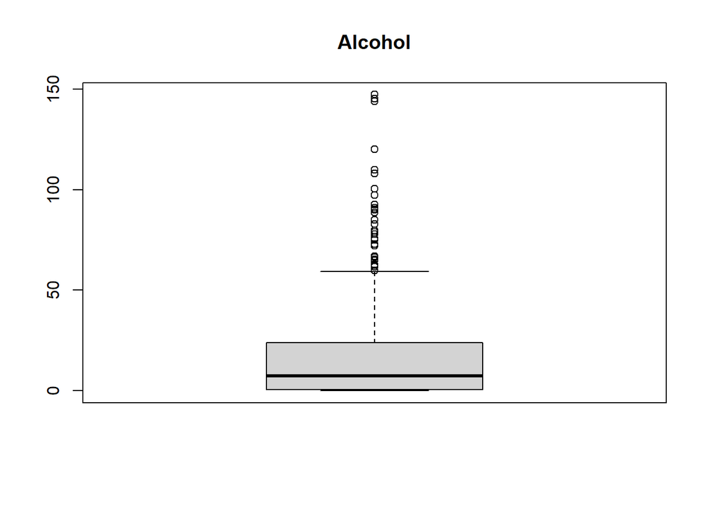

```r
boxplot(datos$alcohol, main="Alcohol")
```

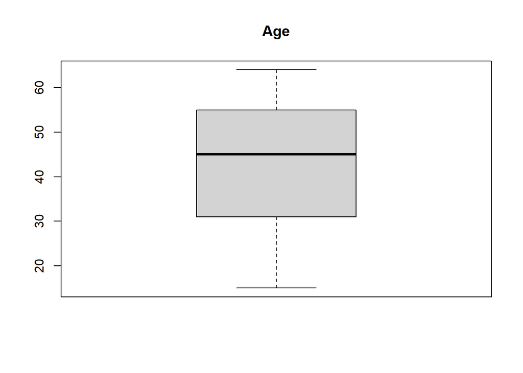

```r
boxplot(datos$age, main= "Age")
```

Al igual que el caso anterior si queremos ver solamente el boxplot de las variables caulitativas no se va a lograr esto debido a su tipo de dato. Sin embargo se podria observar en caso de que se quiera comparar con alguna cuantitaviva. Por ejemplo este caso

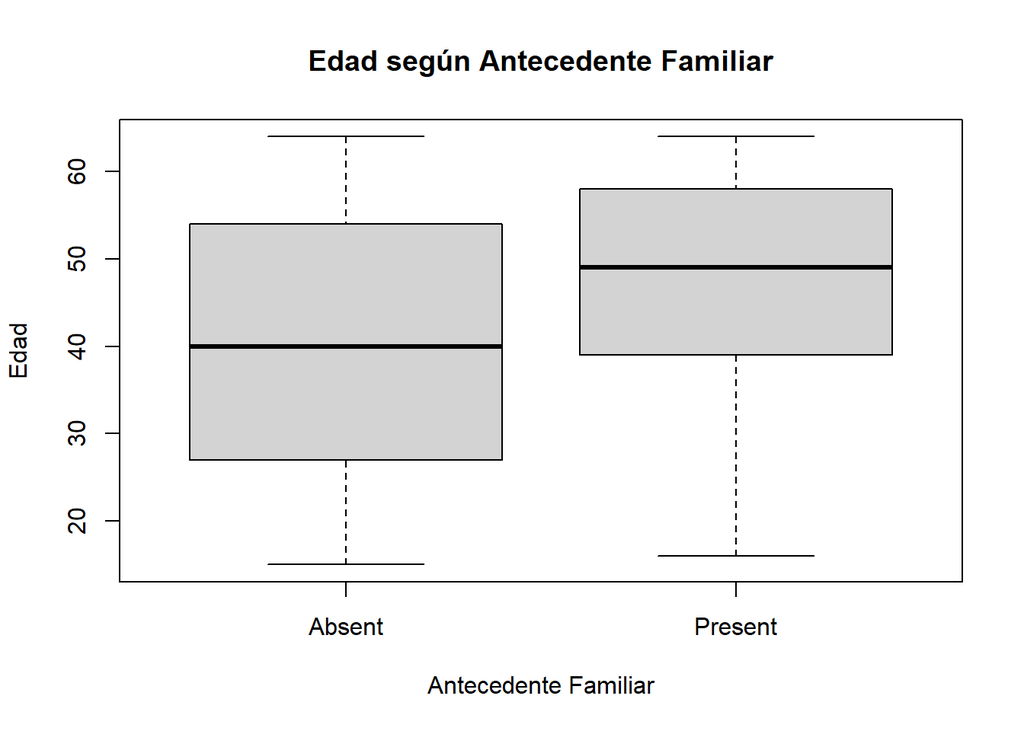

```r
boxplot(datos$age ~ datos$famhist,
        main = "Edad según Antecedente Familiar",
        xlab = "Antecedente Familiar",
        ylab = "Edad")
```

#### Observaciones

sbp  
Se observan algunos valores altos fuera del rango normal, lo que indica personas con presión más elevada que el resto.

tobacco  
Hay varios valores extremos, quiere decir que algunas personas fuman mucho más que la mayoría

ldl  
Los valores se concentran en la parte media, con unos pocos casos de colesterol alto

adiposity  
La mayoría de los datos están en un rango estable, sin muchos valores fuera de lo normal

obesity  
Los datos se agrupan cerca del promedio, aunque hay algunos casos con obesidad más alta

alcohol  
Se ven valores muy altos en pocos casos, lo que muestra que solo unos pocos tienen consumo excesivo.

age  
La mayoría de los participantes son adultos de mediana edad; no se observan edades extremas

# 4. Barplot

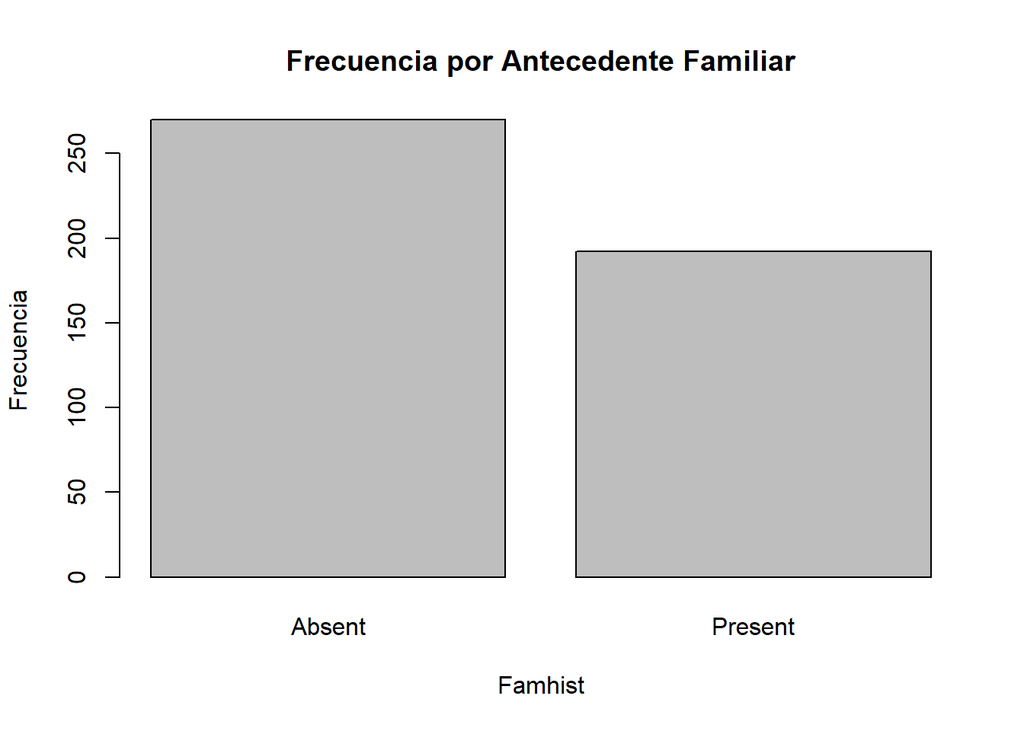

```r
barplot(table(datos$famhist),main = "Frecuencia por Antecedente Familiar",
        xlab = "Famhist",
        ylab = "Frecuencia")
```

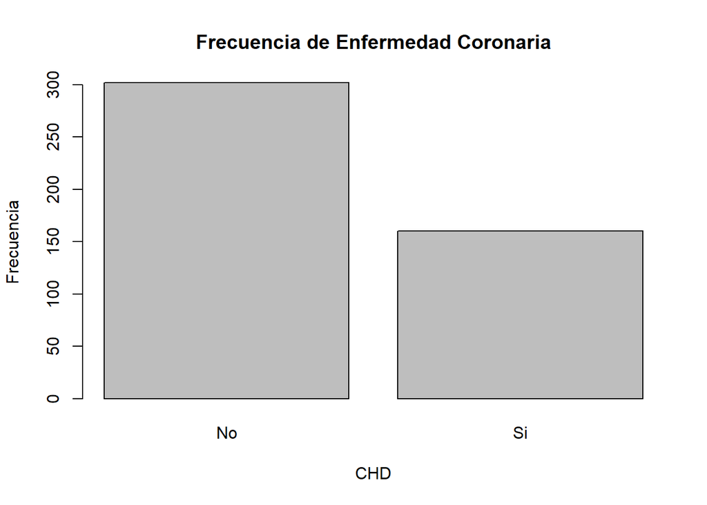

```r
barplot(table(datos$chd), main = "Frecuencia de Enfermedad Coronaria",
        xlab = "CHD",
        ylab = "Frecuencia")
```

#### Observaciones

Frecuencia por Antecedente Familiar - Se observa que la mayoría de las personas no tienen antecedentes familiares de enfermedades cardíacas, aunque existe una parte importante que sí los presenta.

Frecuencia de Enfermedad Coronaria - En este gráfico se aprecia que la cantidad de personas sin enfermedad coronaria es mayor que las que sí la padecen

Se realiza en este caso solo esas 2 ya que este dataset en las variables famhist (antecedentes familiares) y chd (presencia de enfermedad coronaria) son las únicas categóricas.

Los plots de variables numericas no se logran interpretar bien de esta manera en este tipo de visualizacion ya que no se pueden comparar o agrupar.

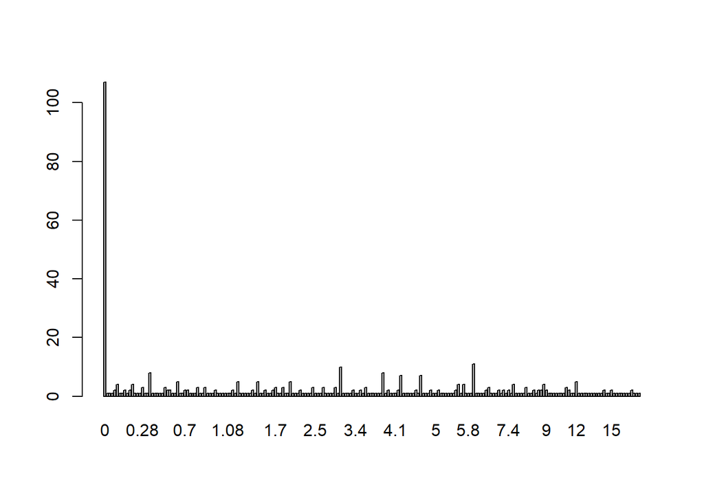

```r
barplot(table(datos$tobacco))
```

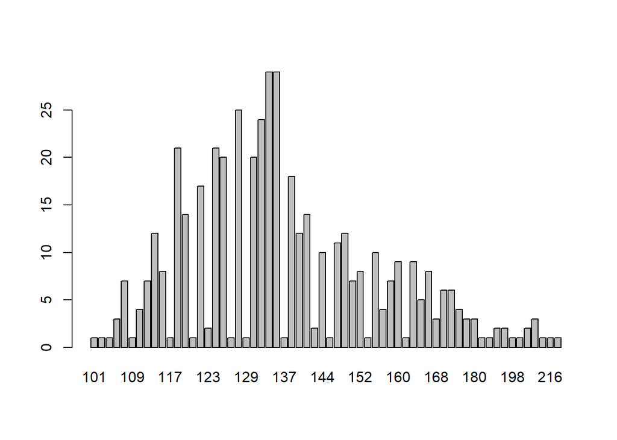

```r
barplot(table(datos$sbp))
```

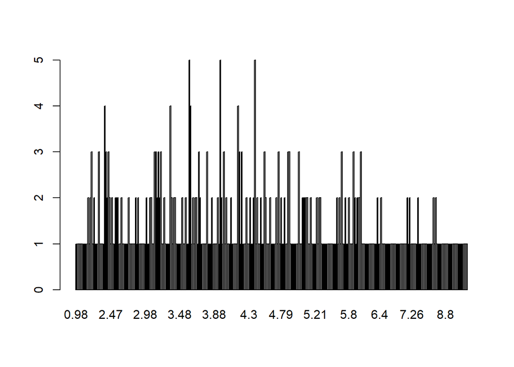

```r
barplot(table(datos$ldl))
```

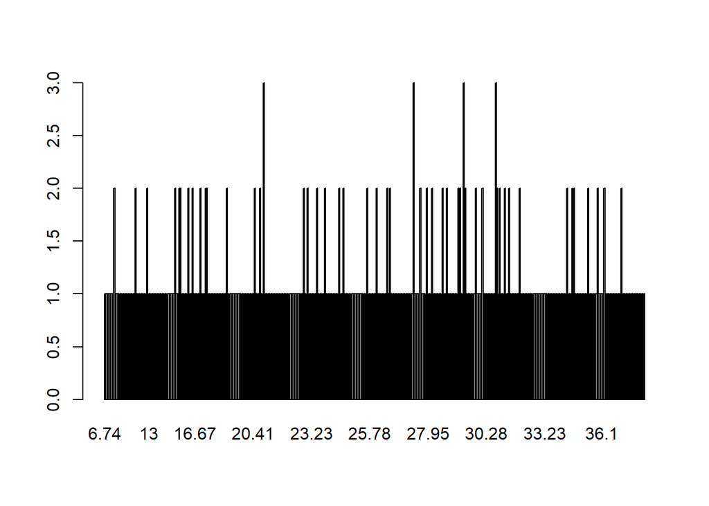

```r
barplot(table(datos$adiposity))
```

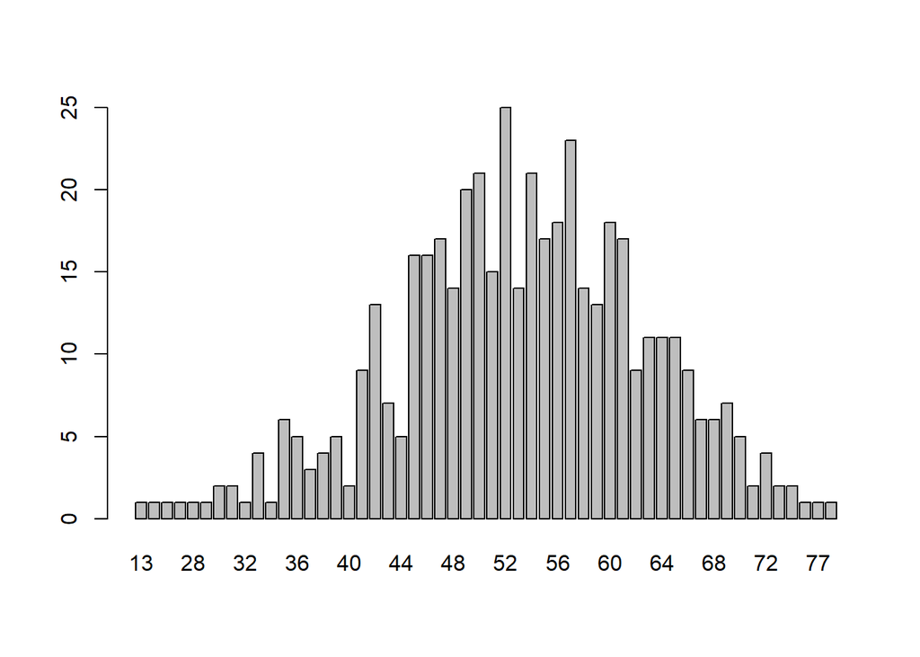

```r
barplot(table(datos$typea))
```

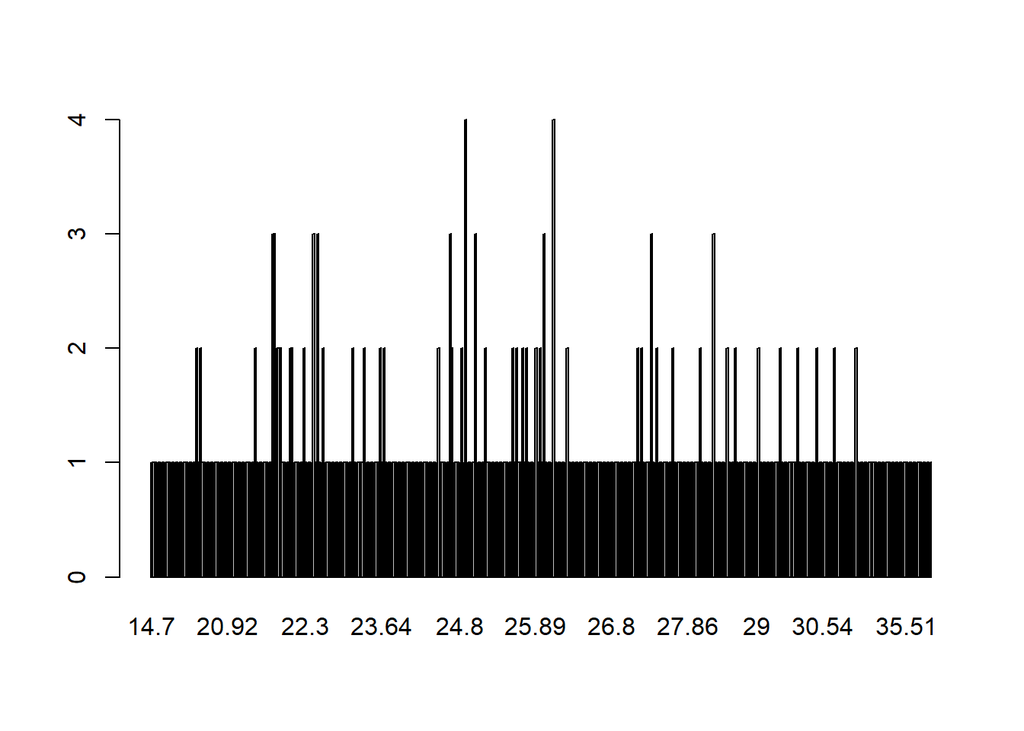

```r
barplot(table(datos$obesity))
```

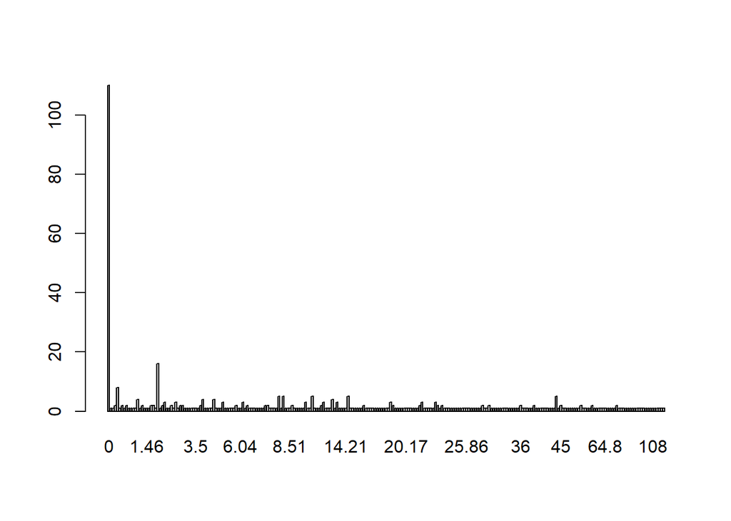

```r
barplot(table(datos$alcohol))
```

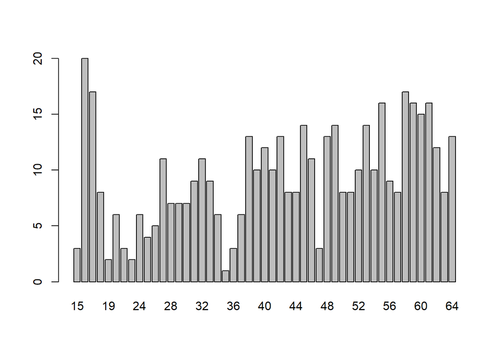

```r
barplot(table(datos$age))
```

# 5. QQline y qqnorm

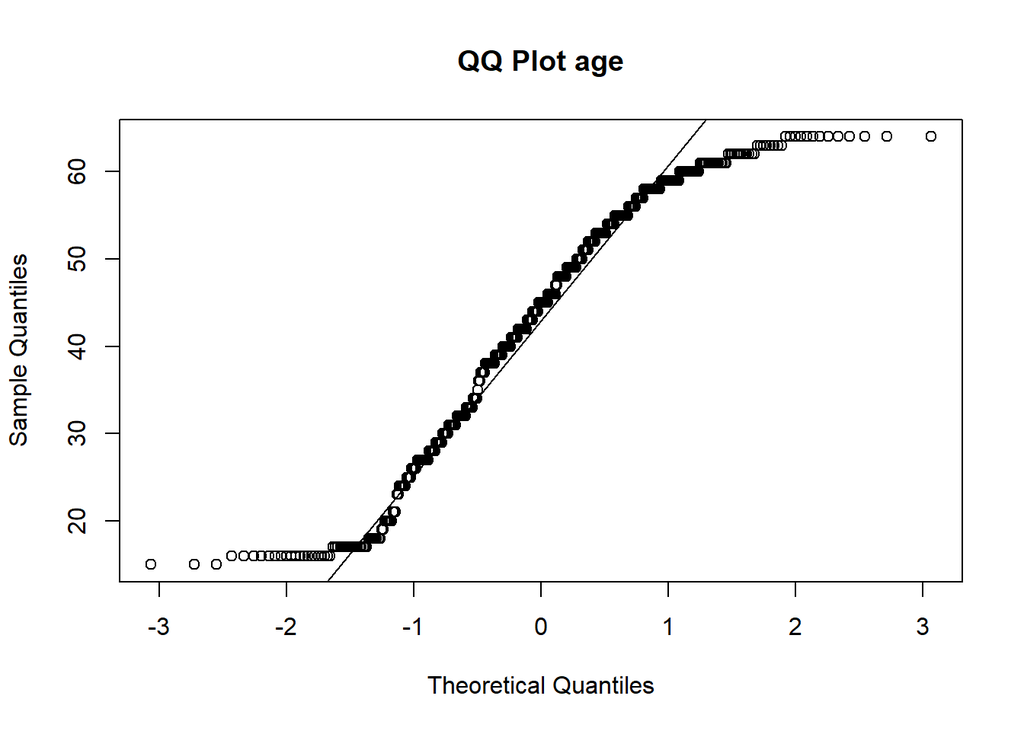

```r
qqnorm(datos$age, main = "QQ Plot age")
qqline(datos$age)
```

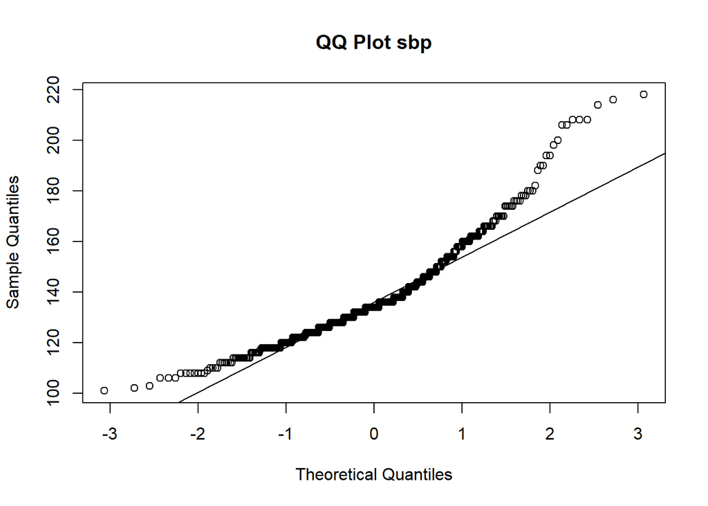

```r
qqnorm(datos$sbp, main = "QQ Plot sbp")
qqline(datos$sbp)
```

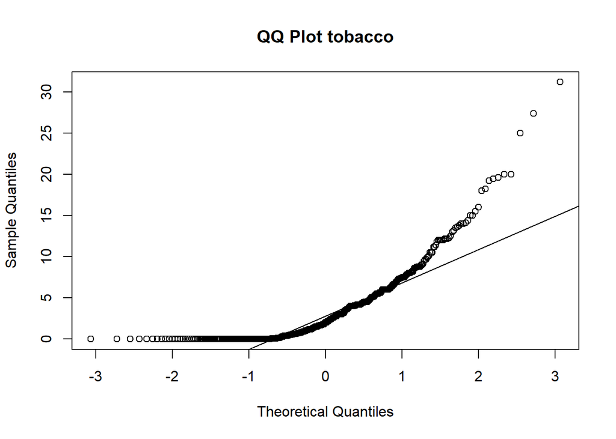

```r
qqnorm(datos$tobacco, main = "QQ Plot tobacco")
qqline(datos$tobacco)
```

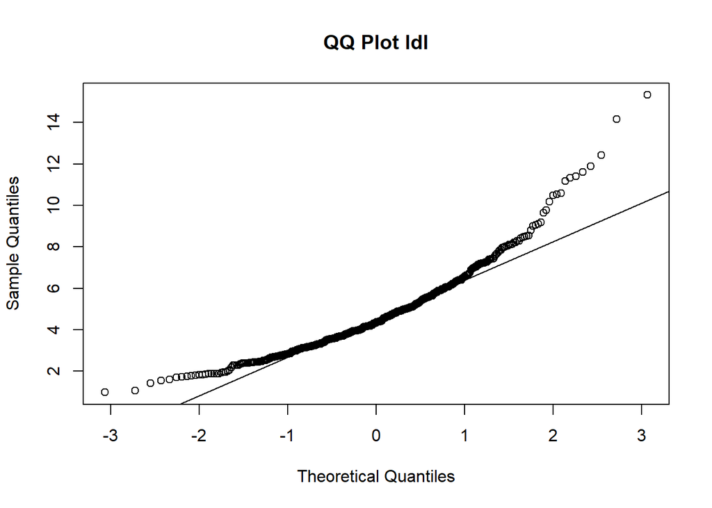

```r
qqnorm(datos$ldl, main = "QQ Plot ldl")
qqline(datos$ldl)
```